# BIOL432 Assignment 8

Edward Chen

2023-03-08

```r
library("dplyr")
library("vegan")
library("tidyr")
library("ggplot2")
library("reshape2")
library("ape")
library("ggtree")
```

## Introduction

The assignment will look at two questions

1. What effect (if any) does garlic mustard have on the plant community?
2. What has a stronger effect on plant communities: the presence/absence of garlic mustard (in/out) of sampling population?

## Part 1

```r
# Reading data as dataframe
survey_data <- read.csv("FloristicSurvey.csv", header=TRUE)
survey_data$Population = as.factor(survey_data$Population)
Population <- (survey_data %>% dplyr::select(Population))
survey_data$Location = as.factor(survey_data$Location)
Location <- survey_data %>% dplyr::select(Location)
survey_data$Quadrate = as.factor(survey_data$Quadrate)
Quadrate <- survey_data %>% dplyr::select(Quadrate)
Info <- cbind(Quadrate, Location, Population)
# Selecting data pertaining to the garlic mustard and other species
species_data <- survey_data %>% dplyr::select(-c(Quadrate:Sillique))
row.names(species_data) <- survey_data$Quadrate
```

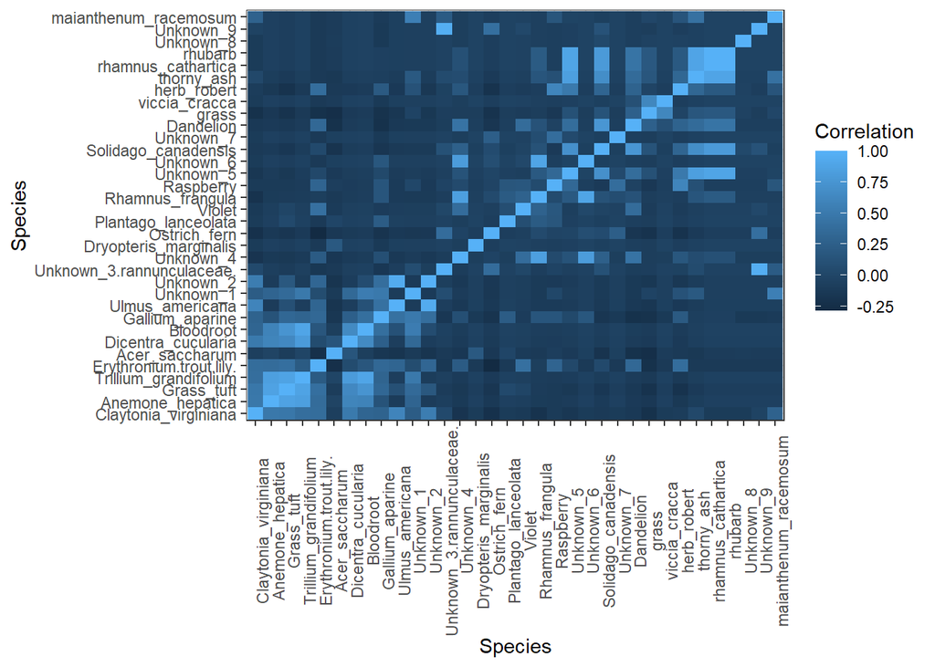

```r
# Checking for correlation
cor_matrix <- cor(species_data)
# Convert the correlation matrix to a long format
cor_matrix_long <- reshape2::melt(cor_matrix)
# Create a heatmap using ggplot2
ggplot(cor_matrix_long, aes(x = Var1, y = Var2, fill = value)) +
  geom_tile() +
  theme_bw() +
  theme(axis.text.x = element_text(angle = 90), legend.title = element_text("Correlation")) + xlab("Species") + ylab("Species")+ labs(fill = "Correlation")
```

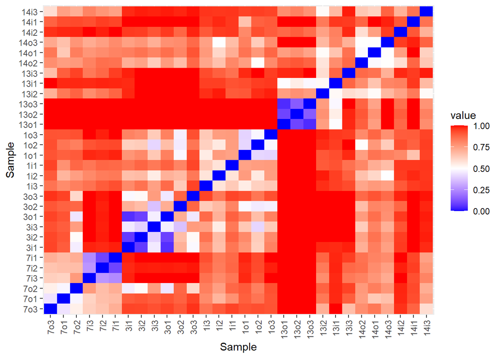

```r
species_dist <- vegdist(species_data,method="bray",binary=F)
species_tree <- nj(species_dist)
species_mat <- as.matrix(species_dist)
species_PDat <- melt(species_mat)

# Visualize the distance matrix
ggplot(data = species_PDat, aes(x = Var1, y = Var2, fill = value)) +
  geom_tile() +
  scale_fill_gradientn(colours = c("blue","white", "red")) +
  xlab("Sample") +
  ylab("Sample") +
  theme(axis.text.x = element_text(angle = 90, hjust = 1, vjust = 0.5))
```

Figure 2: We have each sample/quadrant compared here through the use of a distance map that relies on the Bray-Curtis dissimilarity method. The blue entries signifies that the two compared quadrants are highly similar (the diagonals) while the red signifies that the two quadrants possess very different characteristics.

However, there is a strong indicator that the site of the samples has a stronger effect relative to the presence of garlic mustard plants.

## Part 2

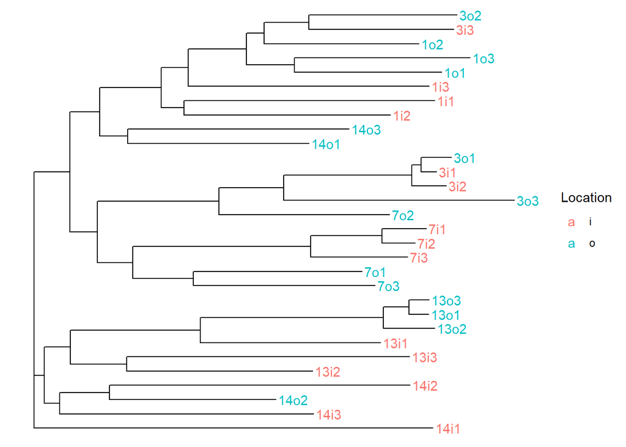

```r
ggtree(species_tree, layout = "rectangular") %<+% Info + geom_tiplab(aes(colour=Location))
```

Figure 3: Based on the previously calculated distance matrix, this tree is constructed. It is grouped by the location or the presence of garlic mustard plants.

Once again, following the previous map figure, it can be observed that certain groups with an absence of garlic mustard plants, such as 13o1, 13o2, and 13o3 are highly isolated from the rest of the sample, but overall, the clustering is not ideal and there is much overlap.

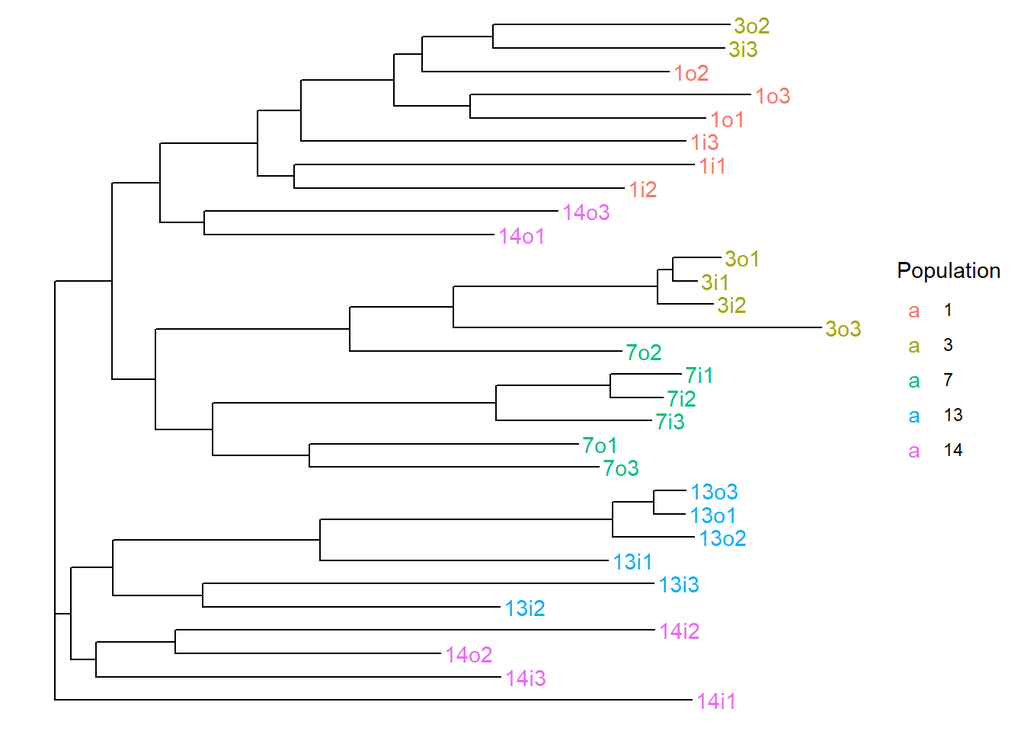

```r
ggtree(species_tree, layout = "rectangular") %<+% Info + geom_tiplab(aes(colour=Population))
```

Figure 4: This is the same tree as the previous figure, but the nodes are highlighted by the site/populations.

Comparatively to the previous figure, it seems that the grouping here are much more distinct, even if there is some overlap. Thus, there is some evidence that the population the same belongs to has a stronger effect on it than the presence of the invasive species. We can further investigate this through the use of clustering by NDMS.

```r
set.seed(1)
NMDSdat <- metaMDS(species_dist, k=2)
```

```
## *** Best solution repeated 1 times
```

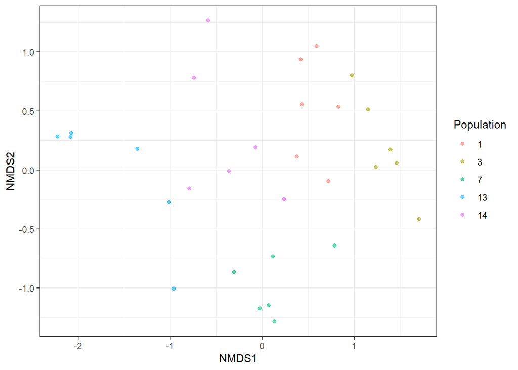

```r
PDat <- data.frame(NMDS1 = NMDSdat$points[,1],
                   NMDS2 = NMDSdat$points[,2],
                   SampleID = row.names(species_data))
PDat <- cbind(PDat, Population, Location)
ggplot(PDat, aes(x = NMDS1, y = NMDS2, color = Population)) +
  geom_point(alpha = 0.6) +
  theme_bw()
```

Figure 5: A bivariate plot to show the NMDS clustering on the dataset. The clusters are the populations/sites.

By clustering in this manner, the groups/populations seem to be quite distinct. Points within a group are relatively close close together comparatively to points outside that group. Therefore, the population has at least some effect on the samples.

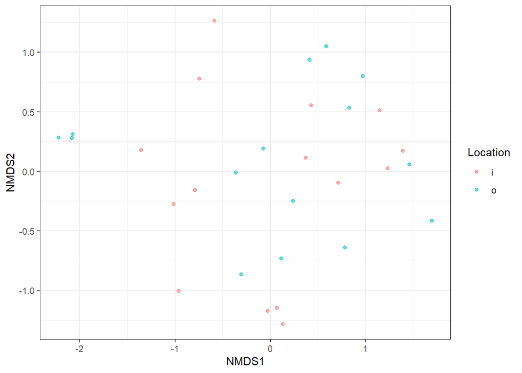

```r
ggplot(PDat, aes(x = NMDS1, y = NMDS2, color = Location)) +
  geom_point(alpha = 0.6) +
  theme_bw()
```

Figure 6: A bivariate plot to show the NMDS clustering on the dataset. The clusters are the location or presence of the garlic mustard plant.

Comparing the two NDMS plots, the one grouped by location has significant overlap between the two groups while the one grouped by population has minimal overlap. Therefore, it can be concluded that there is a high chance that the population has a stronger effect on the plant community relative to the presence or absence of the garlic mustard invasive species.